# 2: Logistic regression

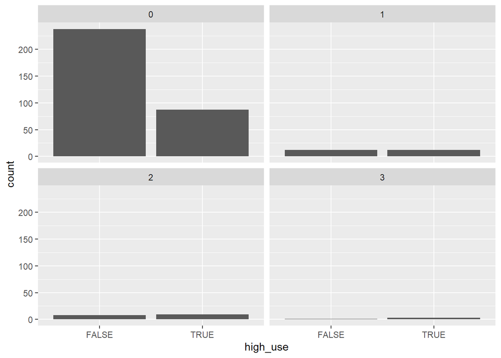

```r
g2 <- ggplot(data = data, aes(x = high_use)) + geom_bar() + facet_wrap("failures")
g2 # this is better
```

```r
#-------------------------------------------------------------------------------------------------
# for goout:
data %>% group_by(high_use) %>% summarise(count = n(), mean_going_out = mean(goout))
```

```
## # A tibble: 2 × 3
##   high_use count mean_going_out
##   <lgl>    <int>          <dbl>
## 1 FALSE      259           2.85
## 2 TRUE       111           3.73
```

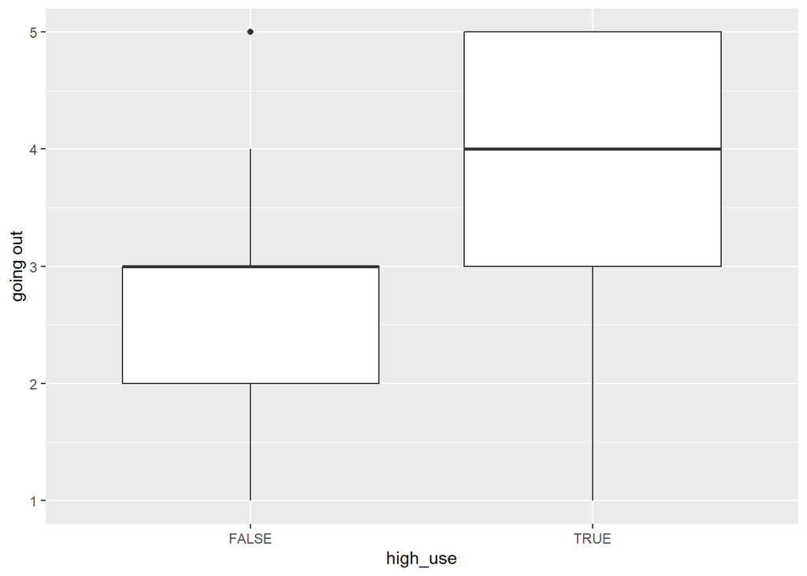

```r
# higher mean or going out more in the group with high use

g1 <- ggplot(data, aes(x = high_use, y = goout)) + geom_boxplot() + ylab("going out")
g1 # looks nice
```

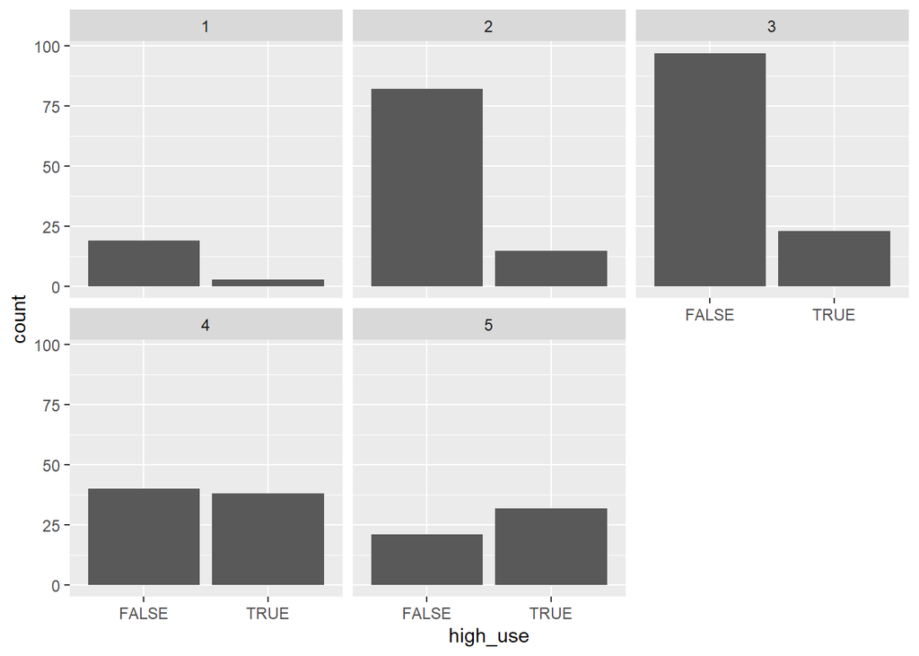

```r
g2 <- ggplot(data = data, aes(x = high_use)) + geom_bar() + facet_wrap("goout")
g2 # a plot for each going out level from 1 (the least) to 5 (the most)
```

It looks like a bigger part of the females are in the group with small consumption, as expected. In males the division is more even, more individuals with a bigger proportion in the high use group.

In the high consumption class the individuals are more outgoing, as hypothesized.

Logistic regression On the variables chosen:

```r
m <- glm(high_use ~ sex + failures + goout, data = data, family = "binomial")

# print out a summary of the model
summary(m)
```

```
##
## Call:
## glm(formula = high_use ~ sex + failures + goout, family = "binomial",
##     data = data)
##
## Coefficients:
##             Estimate Std. Error z value Pr(>|z|)
## (Intercept)  -3.7973     0.4565  -8.318  < 2e-16 ***
## sexM          0.8856     0.2531   3.500 0.000466 ***
## failures      0.5292     0.2288   2.313 0.020732 *
## goout         0.7275     0.1195   6.089 1.13e-09 ***
## ---
## Signif. codes:  0 '***' 0.001 '**' 0.01 '*' 0.05 '.' 0.1 ' ' 1
##
## (Dispersion parameter for binomial family taken to be 1)
##
##     Null deviance: 452.04  on 369  degrees of freedom
## Residual deviance: 383.39  on 366  degrees of freedom
## AIC: 391.39
##
## Number of Fisher Scoring iterations: 4
```

```r
# print out the coefficients of the model
coef(m)
```

```
## (Intercept)        sexM    failures       goout
##  -3.7973068   0.8855768   0.5292036   0.7274660
```

```r
# ORs and their CIs

OR <- coef(m) %>% exp
CI <- confint(m) %>% exp
cbind(OR, CI)
```

```
##                    OR       2.5 %    97.5 %
## (Intercept) 0.0224311 0.008824332 0.0530417
## sexM        2.4243823 1.483028327 4.0075122
## failures    1.6975798 1.092049103 2.6922782
## goout       2.0698290 1.647312988 2.6341765
```

All p-values are < 0.05.

The model includes a categorical variable sex, for which the model p-value indicates that the level M differs from the level F in a statistically significant way. For categorical variables the OR indicated here is not the true OR. For sex-M it is OR(intercept) + OR(sexM) = 0.0224311 + 2.4243823 = 2.446813,indicating that it is a risk factor for high alcohol consumption.

The other ORs are all above 1, so the variables are also risk factors. They increase the outcome by their OR amounts when other variables are kept constant. For example, having a one-unit increase in failures increases the risk of high alcohol consumption by a unit of 1.7 when other variables are kept constant, and likewise for the other variable goout.

To know wether the whole variable sex improves the model fit, we could fit a model without it and compare the models with an anova test.

Explore the predictive power of the model:

```r
# predict() the probability of high_use
probabilities <- predict(m, type = "response")

data <- mutate(data, probability = probabilities)
data <- mutate(data, prediction = probability > 0.5) # probability > 0.5 means it is in the class high consumptio

# tabulate the target variable versus the predictions
table(high_use = data$high_use, prediction = data$prediction)
```

```
##         prediction
## high_use FALSE TRUE
##    FALSE   250    9
##    TRUE     77   34
```

```r
# or like this
table(high_use = data$high_use, prediction = data$prediction) %>% prop.table() %>% addmargins()
```

```
##         prediction
## high_use      FALSE       TRUE        Sum
##    FALSE 0.67567568 0.02432432 0.70000000
##    TRUE  0.20810811 0.09189189 0.30000000
##    Sum   0.88378378 0.11621622 1.00000000
```

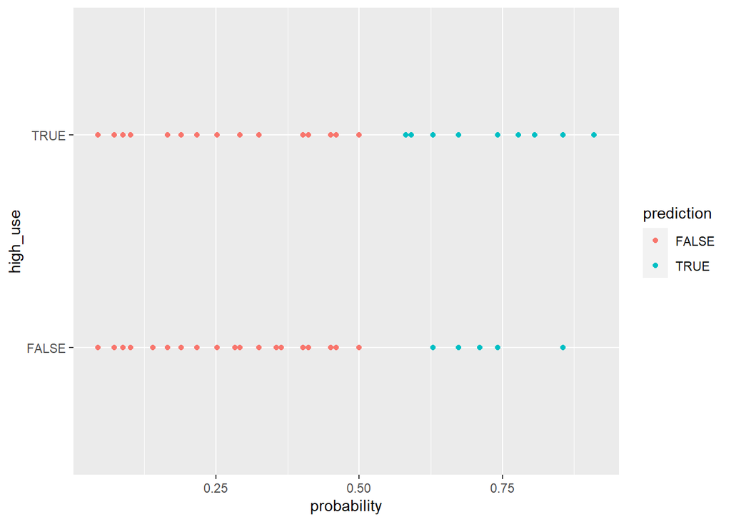

```r
# a plot of the results
g <- ggplot(data, aes(x = probability, y = high_use, col = prediction)) + geom_point()
g
```

```r
# training error
loss_func <- function(class, prob) {
  n_wrong <- abs(class - prob) > 0.5
  mean(n_wrong)
}

loss_func(class = data$high_use, prob = data$probability)
```

```
## [1] 0.2324324
```

```r
# Compare the performance of the model with performance achieved by some simple guessing strategy
# a literal guesser, having 0.5 chance at choosing the correct value
guesses <- sample(c(0,1), nrow(data), replace = T, )
loss_func(class = data$high_use, prob = guesses)
```

```
## [1] 0.5027027
```

```r
# as expected, the guesser is right about half of the time, not being very efficient at predicting
```

```r
cv <- cv.glm(data = data, cost = loss_func, glmfit = m, K = nrow(data))
cv$delta[1]
```

```
## [1] 0.2567568
```

The test error is 26%, which is higher than the training error, as one might expect. It is also about the same compared to that of the model in the excercise set (26%).

Try finding a model with a smaller test error:

```r
m <- glm(high_use ~ sex + failures + goout + age, data = data, family = "binomial")
cv <- cv.glm(data = data, cost = loss_func, glmfit = m, K = nrow(data))
cv$delta[1]
```

```
## [1] 0.2054054
```

The test error is 21%, which is now smaller than in the excercise.